# Ford GoBike System Data Analysis

## Preliminary Wrangling

> This data set includes information about individual rides made in a bike-sharing system covering the greater San Francisco Bay area.

```python
# import all packages and set plots to be embedded inline
import numpy as np
import pandas as pd
import matplotlib.pyplot as plt
import seaborn as sb

%matplotlib inline
```

```python
# Load in the dataset and investigate the first few rows
df = pd.read_csv('201902-fordgobike-tripdata.csv')
df.head()
```

|  | duration_sec | start_time | end_time | start_station_id | start_station_name | start_station_latitude | start_station_longitude | end_station_id | end_station_name | end_station_latitude | end_station_longitude | bike_id | user_type | member_birth_year | member_gender | bike_share_for_all_trip |
| --- | --- | --- | --- | --- | --- | --- | --- | --- | --- | --- | --- | --- | --- | --- | --- | --- |
| 0 | 52185 | 2019-02-28 17:32:10.1450 | 2019-03-01 08:01:55.9750 | 21.0 | Montgomery St BART Station (Market St at 2nd St) | 37.789625 | -122.400811 | 13.0 | Commercial St at Montgomery St | 37.794231 | -122.402923 | 4902 | Customer | 1984.0 | Male | No |
| 1 | 42521 | 2019-02-28 18:53:21.7890 | 2019-03-01 06:42:03.0560 | 23.0 | The Embarcadero at Steuart St | 37.791464 | -122.391034 | 81.0 | Berry St at 4th St | 37.775880 | -122.393170 | 2535 | Customer | NaN | NaN | No |
| 2 | 61854 | 2019-02-28 12:13:13.2180 | 2019-03-01 05:24:08.1460 | 86.0 | Market St at Dolores St | 37.769305 | -122.426826 | 3.0 | Powell St BART Station (Market St at 4th St) | 37.786375 | -122.404904 | 5905 | Customer | 1972.0 | Male | No |
| 3 | 36490 | 2019-02-28 17:54:26.0100 | 2019-03-01 04:02:36.8420 | 375.0 | Grove St at Masonic Ave | 37.774836 | -122.446546 | 70.0 | Central Ave at Fell St | 37.773311 | -122.444293 | 6638 | Subscriber | 1989.0 | Other | No |
| 4 | 1585 | 2019-02-28 23:54:18.5490 | 2019-03-01 00:20:44.0740 | 7.0 | Frank H Ogawa Plaza | 37.804562 | -122.271738 | 222.0 | 10th Ave at E 15th St | 37.792714 | -122.248780 | 4898 | Subscriber | 1974.0 | Male | Yes |

```python
# Investigate the dataset dimensions
df.shape
```

```
(183412, 16)
```

```python
# Investigate the data types of the columns
df.dtypes
```

```
duration_sec                 int64
start_time                  object
end_time                    object
start_station_id           float64
start_station_name          object
start_station_latitude     float64
start_station_longitude    float64
end_station_id             float64
end_station_name            object
end_station_latitude       float64
end_station_longitude      float64
bike_id                      int64
user_type                   object
member_birth_year          float64
member_gender               object
bike_share_for_all_trip     object
dtype: object
```

```python
# Detect number of missing values in each column
df.isnull().sum()
```

```
duration_sec                  0
start_time                    0
end_time                      0
start_station_id            197
start_station_name          197
start_station_latitude        0
start_station_longitude       0
end_station_id              197
end_station_name            197
end_station_latitude          0
end_station_longitude         0
bike_id                       0
user_type                     0
member_birth_year          8265
member_gender              8265
bike_share_for_all_trip       0
dtype: int64
```

###### Missing values in names and IDs of start stations and end stations is not a significant problem as soon as their locations in terms of longitudes and lattitudes are known, we can conclude the name of the location from other dataset rows or with a simple online search from the longitude and the latitude of the station

###### Missing values in gender is not as important as other features like being a customer or subscriber for example, so there is no need to remove the whole rows from the dataset. When analysing gender we will note that there are missing values

###### The birth year column will be used to compute another column 'age' to register the age of each member instead, the mean of the ages will be put for the missing values

```python
# Create new 'age' column to compute members' ages in 2019
df['age'] = 2019 - df['member_birth_year']
```

```python
# Filling the missing values in the age column with mean
df['age'].fillna(df['age'].mean(), inplace = True)
# Change the age column to int data type
df['age'] = df['age'].astype(int)
# Check results
df.head()
```

|  | duration_sec | start_time | end_time | start_station_id | start_station_name | start_station_latitude | start_station_longitude | end_station_id | end_station_name | end_station_latitude | end_station_longitude | bike_id | user_type | member_birth_year | member_gender | bike_share_for_all_trip | age |
| --- | --- | --- | --- | --- | --- | --- | --- | --- | --- | --- | --- | --- | --- | --- | --- | --- | --- |
| 0 | 52185 | 2019-02-28 17:32:10.1450 | 2019-03-01 08:01:55.9750 | 21.0 | Montgomery St BART Station (Market St at 2nd St) | 37.789625 | -122.400811 | 13.0 | Commercial St at Montgomery St | 37.794231 | -122.402923 | 4902 | Customer | 1984.0 | Male | No | 35 |
| 1 | 42521 | 2019-02-28 18:53:21.7890 | 2019-03-01 06:42:03.0560 | 23.0 | The Embarcadero at Steuart St | 37.791464 | -122.391034 | 81.0 | Berry St at 4th St | 37.775880 | -122.393170 | 2535 | Customer | NaN | NaN | No | 34 |
| 2 | 61854 | 2019-02-28 12:13:13.2180 | 2019-03-01 05:24:08.1460 | 86.0 | Market St at Dolores St | 37.769305 | -122.426826 | 3.0 | Powell St BART Station (Market St at 4th St) | 37.786375 | -122.404904 | 5905 | Customer | 1972.0 | Male | No | 47 |
| 3 | 36490 | 2019-02-28 17:54:26.0100 | 2019-03-01 04:02:36.8420 | 375.0 | Grove St at Masonic Ave | 37.774836 | -122.446546 | 70.0 | Central Ave at Fell St | 37.773311 | -122.444293 | 6638 | Subscriber | 1989.0 | Other | No | 30 |
| 4 | 1585 | 2019-02-28 23:54:18.5490 | 2019-03-01 00:20:44.0740 | 7.0 | Frank H Ogawa Plaza | 37.804562 | -122.271738 | 222.0 | 10th Ave at E 15th St | 37.792714 | -122.248780 | 4898 | Subscriber | 1974.0 | Male | Yes | 45 |

```python
# Converting the start time and end time columns from string to datetime datatype
df['start_time'] = pd.to_datetime(df['start_time'])
df['end_time'] = pd.to_datetime(df['end_time'])
```

```python
# Convert start time to days and hours columns
df['start_day'] = df['start_time'].dt.day_name()
df['start_hour'] = df['start_time'].dt.hour
```

```python
# Check results
df.head()
```

|  | duration_sec | start_time | end_time | start_station_id | start_station_name | start_station_latitude | start_station_longitude | end_station_id | end_station_name | end_station_latitude | end_station_longitude | bike_id | user_type | member_birth_year | member_gender | bike_share_for_all_trip | age | start_day | start_hour |
| --- | --- | --- | --- | --- | --- | --- | --- | --- | --- | --- | --- | --- | --- | --- | --- | --- | --- | --- | --- |
| 0 | 52185 | 2019-02-28 17:32:10.145 | 2019-03-01 08:01:55.975 | 21.0 | Montgomery St BART Station (Market St at 2nd St) | 37.789625 | -122.400811 | 13.0 | Commercial St at Montgomery St | 37.794231 | -122.402923 | 4902 | Customer | 1984.0 | Male | No | 35 | Thursday | 17 |
| 1 | 42521 | 2019-02-28 18:53:21.789 | 2019-03-01 06:42:03.056 | 23.0 | The Embarcadero at Steuart St | 37.791464 | -122.391034 | 81.0 | Berry St at 4th St | 37.775880 | -122.393170 | 2535 | Customer | NaN | NaN | No | 34 | Thursday | 18 |
| 2 | 61854 | 2019-02-28 12:13:13.218 | 2019-03-01 05:24:08.146 | 86.0 | Market St at Dolores St | 37.769305 | -122.426826 | 3.0 | Powell St BART Station (Market St at 4th St) | 37.786375 | -122.404904 | 5905 | Customer | 1972.0 | Male | No | 47 | Thursday | 12 |
| 3 | 36490 | 2019-02-28 17:54:26.010 | 2019-03-01 04:02:36.842 | 375.0 | Grove St at Masonic Ave | 37.774836 | -122.446546 | 70.0 | Central Ave at Fell St | 37.773311 | -122.444293 | 6638 | Subscriber | 1989.0 | Other | No | 30 | Thursday | 17 |
| 4 | 1585 | 2019-02-28 23:54:18.549 | 2019-03-01 00:20:44.074 | 7.0 | Frank H Ogawa Plaza | 37.804562 | -122.271738 | 222.0 | 10th Ave at E 15th St | 37.792714 | -122.248780 | 4898 | Subscriber | 1974.0 | Male | Yes | 45 | Thursday | 23 |

```python
# Investigate summary statistics
df.describe()
```

|  | duration_sec | start_station_id | start_station_latitude | start_station_longitude | end_station_id | end_station_latitude | end_station_longitude | bike_id | member_birth_year | age | start_hour |
| --- | --- | --- | --- | --- | --- | --- | --- | --- | --- | --- | --- |
| count | 183412.000000 | 183215.000000 | 183412.000000 | 183412.000000 | 183215.000000 | 183412.000000 | 183412.000000 | 183412.000000 | 175147.000000 | 183412.000000 | 183412.000000 |
| mean | 726.078435 | 138.590427 | 37.771223 | -122.352664 | 136.249123 | 37.771427 | -122.352250 | 4472.906375 | 1984.806437 | 34.184841 | 13.458421 |
| std | 1794.389780 | 111.778864 | 0.099581 | 0.117097 | 111.515131 | 0.099490 | 0.116673 | 1664.383394 | 10.116689 | 9.886200 | 4.724978 |
| min | 61.000000 | 3.000000 | 37.317298 | -122.453704 | 3.000000 | 37.317298 | -122.453704 | 11.000000 | 1878.000000 | 18.000000 | 0.000000 |
| 25% | 325.000000 | 47.000000 | 37.770083 | -122.412408 | 44.000000 | 37.770407 | -122.411726 | 3777.000000 | 1980.000000 | 27.000000 | 9.000000 |
| 50% | 514.000000 | 104.000000 | 37.780760 | -122.398285 | 100.000000 | 37.781010 | -122.398279 | 4958.000000 | 1987.000000 | 32.000000 | 14.000000 |
| 75% | 796.000000 | 239.000000 | 37.797280 | -122.286533 | 235.000000 | 37.797320 | -122.288045 | 5502.000000 | 1992.000000 | 38.000000 | 17.000000 |
| max | 85444.000000 | 398.000000 | 37.880222 | -121.874119 | 398.000000 | 37.880222 | -121.874119 | 6645.000000 | 2001.000000 | 141.000000 | 23.000000 |

### What is the final structure of the dataset?

> There are 183412 members who shared bikes with 16 given features : duration_sec, start_time, end_time, start_station_id, start_station_name, start_station_latitude, start_station_longitude, end_station_id, end_station_name, end_station_latitude, end_station_longitude, bike_id, user_type, member_birth_year, member_gender, bike_share_for_all_trip. Another 3 features are extracted and added : start_day and start hour from start_time, and age from member_birth_year to end having 183412 members with 19 fetaures

### What is/are the main feature(s) of interest in the dataset?

> I am interseted in the time and location in which most trips are taken. There is also another concern about factors that may affect the trip duration like user type, start day or hour

### What features in the dataset are thought to help support investigation into feature(s) of interest?

> There are many features of interest, the start day, hour and location of the trips and the user type

## Univariate Exploration

> Let's investigate when most trips are taken in terms of days

```python
# A function to compute frequncy of each level of a categorical variable
def categ_freq(x, order, xlabel, ylabel ,title):
    """A function to compute the frequency of each level of a categorical variable
    x (string): The column name of a categorical variable
    order (series): order of plotting levels of the categorical variable
    xlabel (string): label for x-axis
    ylabel (string): label for y-axis
    title (string): The title of the plot
    """
    plt.figure(figsize = [8, 5])
    sb.countplot(data = df, x = x, order = order, color = sb.color_palette()[0])
    plt.xlabel(xlabel, fontsize= 12)
    plt.ylabel(ylabel, fontsize=12)
    plt.title(title, fontsize=14)
```

```python
# A function to compute a hsitogram
def hist(x, bins, xlabel, ylabel, title):
    """A function to compute the histogram for a given column name
    x (string): The column name of a variable
    bins (list): bin edge for each column
    xlabel (string): label for x-axis
    """
    plt.figure(figsize = [8, 5])
    plt.hist(data = df, x = x, bins = bins)
    plt.xlabel(xlabel, fontsize= 12)
    plt.ylabel(ylabel, fontsize=12)
    plt.title(title, fontsize=14)
```

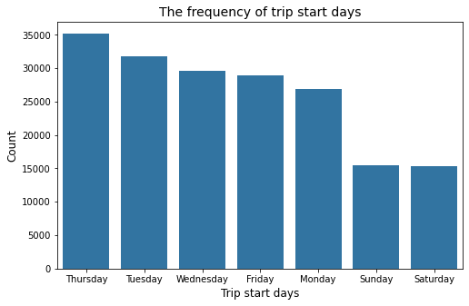

```python
# The distribution of the start day
categ_freq('start_day', df['start_day'].value_counts().index, "Trip start days", "Count", "The frequency of trip start days")
```

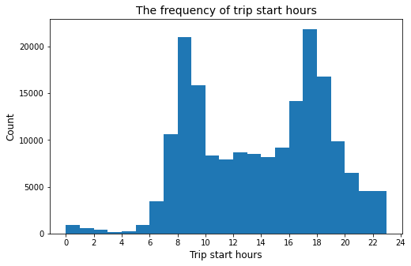

```python
# The distribution of the start hours
bins = np.arange(0, 23+1, 1)
hist('start_hour', bins, 'Trip start hours', 'Count', 'The frequency of trip start hours')
plt.xticks(np.arange(0, 25, 2), np.arange(0, 25, 2));
```

> The distribution of start hours is bimodal, most of trips starts between 7 am and 9 pm (21) with one peak at 8 am and the other peak is at 5 pm (17). Now, we will look at the distribution of ages of members

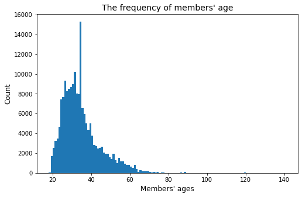

```python
# The distribution of members' ages
bins = np.arange(df['age'].min(), df['age'].max()+1, 1)
hist('age', bins, "Members' ages", 'Count', "The frequency of members' age")
```

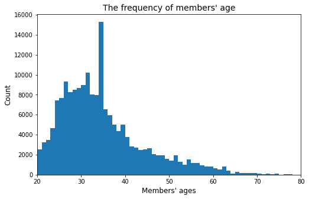

```python
# let's zoom in between 20 and 80
bins = np.arange(df['age'].min(), df['age'].max()+1, 1)
hist('age', bins, "Members' ages", 'Count', "The frequency of members' age")
plt.xlim(20, 80);
```

> It seems like it has a long tail, let's try the log scale

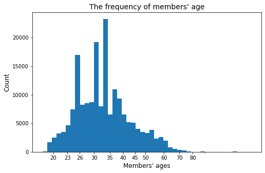

```python
# The distribution of members' ages in a log scale
bins = 10 ** np.arange(np.log10(df['age']).min(), np.log10(df['age']).max()+0.02, 0.02)
hist('age', bins, "Members' ages", 'Count', "The frequency of members' age")
plt.xscale('log')
ticks = [20, 23, 26, 30, 35, 40, 45 ,50, 60, 70, 80]
plt.xticks(ticks, ticks);
```

> Taking into consideration that we have substituted missing values with the mean, most of the members' ages are between 24 and 40 with peaks between 25 and 26, 30 and 31 and the greatest peak is between 34 and 35 which means that most of members are in their mid thirties. Also there exist some outliers like the one of age 141. Next, we will investigate which type of users exists the most, subsribers or customers.

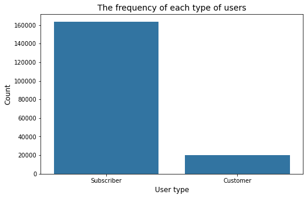

```python
# The frequency of users' types
categ_freq('user_type', df['user_type'].value_counts().index, "User type", "Count", "The frequency of each type of users")
```

> It is clear that 160 k of users are subscribers while only 20 k of users are customers. It's time to investigate the trip duration.

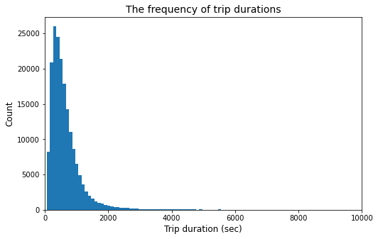

```python
# The distribution of trips' durations in a standard scale
bins = np.arange(df['duration_sec'].min(), df['duration_sec'].max()+100, 100)
hist('duration_sec', bins, 'Trip duration (sec)', 'Count', 'The frequency of trip durations')
plt.xlim(0, 10000);
```

> The values are of several order of magnitudes and there is a long tail in the distribution so let's try a log scale

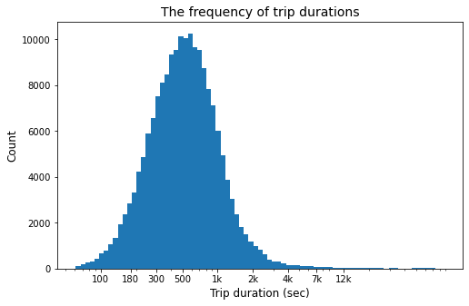

```python
# The distribution of trips' durations in a log scale
bins = 10 ** np.arange(np.log10(df['duration_sec']).min(), np.log10(df['duration_sec']).max()+0.04, 0.04)
hist('duration_sec', bins, 'Trip duration (sec)', 'Count', 'The frequency of trip durations')
plt.xscale('log')
ticks = [100, 180, 300, 500, 1000, 2000, 4000 ,7000 ,12000]
ticks_labels = ['100', '180', '300', '500', '1k', '2k', '4k' ,'7k' ,'12k']
plt.xticks(ticks, ticks_labels);
```

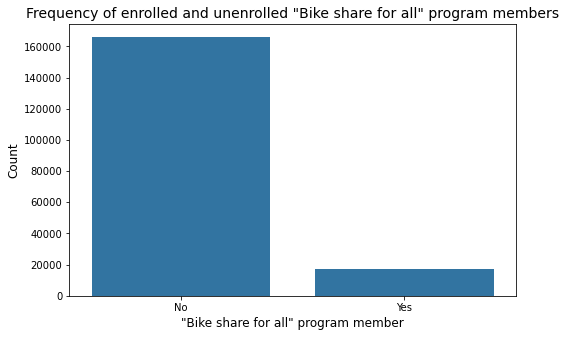

```python
# The frequency of enrolled members in the 'Bike Share for All' program
categ_freq('bike_share_for_all_trip', df['bike_share_for_all_trip'].value_counts().index, '"Bike share for all" program member', 'Count', 'Frequency of enrolled and unenrolled "Bike share for all" program members')
```

> Only 20k members which is about 11% of all members are enrolled in the 'Bike Share for All' program. Finally in the univariate exploration section we will see the gender distribution among trips, note that there are 8265 missing values.

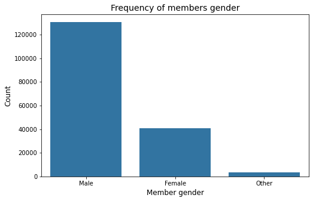

```python
# Gender distribution
categ_freq('member_gender', df['member_gender'].value_counts().index, 'Member gender', 'Count', 'Frequency of members gender')
```

### Discussion of the distribution(s) of variable(s) of interest. Were there any unusual points? Did we need to perform any transformations?

> There are unusual points in the 'age' variable, there is an unusual point which is the age of member of 141 years. Also the 'duration_sec' have a long tail and several values of different order of magnitudes so a transformation of a log scale is applied to have a normal distribution

## Bivariate Exploration

> Let's compare between both user types in terms of the average duration of trips

```python
# A function to plot catgegorical levels Vs quantitative variables
def categ_quant(x, y, xlabel, ylabel, title):
    """
    This function plots the levels of the catgerical variable of 'x' Vs the average of the quantitative variable 'y'
    x (string): column name of a categorical variable
    y (string): column name of a quantitative variable
    """
    plt.figure(figsize = [8, 5])
    sb.barplot(data = df, x = x, y = y, color = sb.color_palette()[0], errwidth = 0);
    plt.xlabel(xlabel, fontsize= 12)
    plt.ylabel(ylabel, fontsize=12)
    plt.title(title, fontsize=14)
```

```python
# A function to create plots between numerical variables via scatter plot
def scatter(x, y, xlabel, ylabel, title, z = None):
    """
    This function creates a scatter plot between two quantitative variables 'x' and 'y'
    x (string): column name of x-axis variable
    y (string): column name of y-axis variable
    z (string): column name of third variable to plot via color
    xlabel(string): label for x-axis
    ylabel(string): label for y-axis
    title(string): plot title
    """
    plt.figure(figsize = [8, 5])
    sb.scatterplot(data = df, x = x, y = y, hue = z);
    plt.xlabel(xlabel, fontsize= 12)
    plt.ylabel(ylabel, fontsize=12)
    plt.title(title, fontsize=14)
```

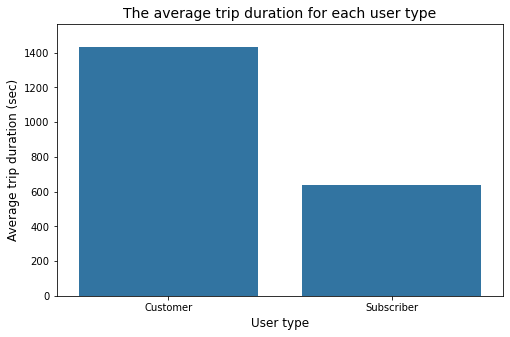

```python
# Investigating duration-user_type relationship
categ_quant('user_type', 'duration_sec', 'User type', 'Average trip duration (sec)', 'The average trip duration for each user type')
```

> It is clear that customers have larger trip durations than subscribers in average, customers have about 1400 seconds (23 minutes) while subscribers have about 600 seconds (10 minutes) in average. Next we will investigate the effect of being enrolled in the 'bike share for all program' on the trip duration.

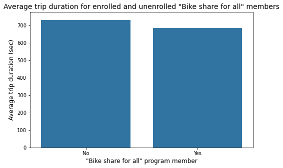

```python
# Investigating duration-'bike share for all' program members relationship
categ_quant('bike_share_for_all_trip', 'duration_sec', '"Bike share for all" program member', 'Average trip duration (sec)', 'Average trip duration for enrolled and unenrolled "Bike share for all" members')
```

> It seems like that there is no significant difference in trip duration whether a member is in the 'bike share for all' program or not. Next we'll see the start hour effect on the trip duration

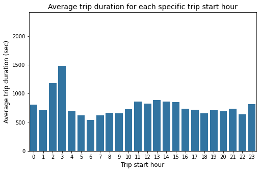

```python
# Start hour Vs trip duration
categ_quant('start_hour', 'duration_sec', 'Trip start hour', 'Average trip duration (sec)', 'Average trip duration for each specific trip start hour')
```

> It is clear that members that starts their trips at 2 am or 3 am have the longest trip duartions on average. Next we'll investigate which gender have longer trip duration

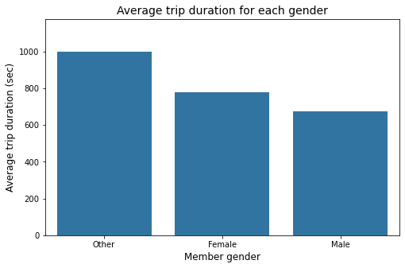

```python
# Gender Vs trip duration
plt.figure(figsize = [8, 5])
sb.barplot(data = df, x = 'member_gender', y = 'duration_sec', color = sb.color_palette()[0], order = ['Other', 'Female', 'Male'], errwidth = 0);
plt.xlabel('Member gender', fontsize= 12)
plt.ylabel('Average trip duration (sec)', fontsize=12)
plt.title('Average trip duration for each gender', fontsize=14);
```

> Members who are not males nor females have the longest trip duration in average. Next we'll see age distribution among hours of the day

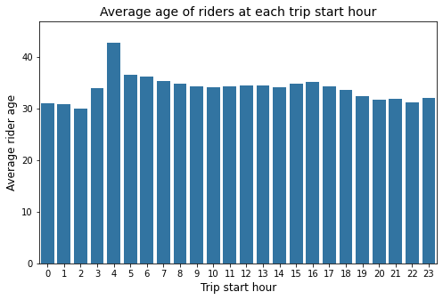

```python
# Start hour Vs member age
categ_quant('start_hour', 'age', 'Trip start hour', 'Average rider age', 'Average age of riders at each trip start hour')
```

> It is interesting to know that members ate their mid fourties in average starts their trips early at 4 am, and there is a slight decrease in ages as we go towards the mid and end of day. Finally we will investiagte teh distribution of stations in terms of longitudes and latitudes

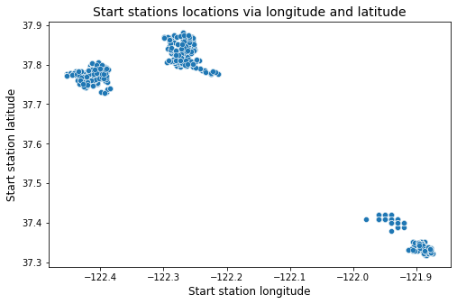

```python
# start location distribution
scatter('start_station_longitude', 'start_station_latitude', 'Start station longitude', 'Start station latitude', 'Start stations locations via longitude and latitude')
```

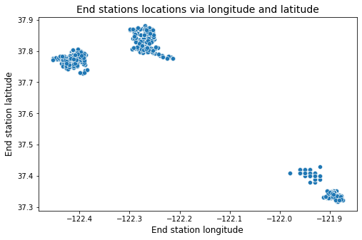

```python
# End location distribution
scatter('end_station_longitude', 'end_station_latitude', 'End station longitude', 'End station latitude', 'End stations locations via longitude and latitude')
```

> It is clear that start and end stations are distributed among four main clusters, the largest cluster cnetred at -122.25 longitude and 37.85 latitude, then a smaller cluster at -122.4 longitude and 37.78 latitude, then smaller one at -121.95 longitude and 37.4 latitude then the smallest on at -121.85 longitude and 37.35 latitude

### Did you observe any interesting relationships between the other features (not the main feature(s) of interest)?

> The time in a day is investigated Vs age, and it is interesting to know that members at their mid fourties in average starts their trips earlier than those who are younger

## Multivariate Exploration

> Let's investigate the location of start station Vs gender of members

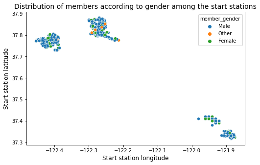

```python
# start location vs gender
scatter('start_station_longitude', 'start_station_latitude', 'Start station longitude', 'Start station latitude', 'Distribution of members according to gender among the start stations', 'member_gender');
```

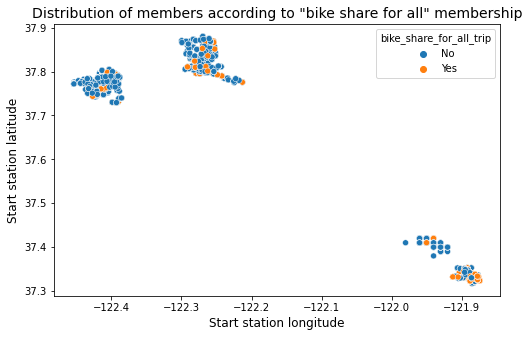

```python
# start location vs "bike share for all" program members
scatter('start_station_longitude', 'start_station_latitude', 'Start station longitude', 'Start station latitude', 'Distribution of members according to "bike share for all" membership', 'bike_share_for_all_trip');
```